# Enrichment Analysis of H3K27ac peaks (enhancer) with high correlation

last changed: 2023-08-29

# Enrichment analysis H3K27ac enhancer (high correlation)

## Data processing

To identify those enhancers with either high positive (R >= 0.7) or high negative (R <= -0.7) correlation the data frame containing those information was loaded and filtered.

```r
> corr.enhcr <- readRDS("./../Compare_H3K27ac_RNAseq/Data/data.cor.rds")
>
> head(corr.enhcr)
```

```
##       U2OS31     U2OS33            gene            ENSG        GHid
## 1  0.8125722  0.7161036        C1QTNF12 ENSG00000184163 GH01J037944
## 2  0.1437006  0.1469810 ENSG00000284699 ENSG00000284699 GH11J041306
## 3 -0.8981119 -0.5715487            RCC1 ENSG00000180198 GH22J028115
## 4 -0.5468799 -0.5064761           TAF12 ENSG00000120656 GH05J058261
## 5  0.4171535 -0.3878030          INPP5B ENSG00000204084 GH18J045805
## 6 -0.8669090 -0.9186477         ST3GAL3 ENSG00000126091 GH05J042894
##                      peak cluster                                 codeID
## 1  chr1:37945475-37947753       1         C1QTNF12chr1:37945475-37947753
## 2 chr11:41306087-41307140       1 ENSG00000284699chr11:41306087-41307140
## 3 chr22:28114814-28118426       1            RCC1chr22:28114814-28118426
## 4  chr5:58256648-58261930       1            TAF12chr5:58256648-58261930
## 5 chr18:45805912-45807154       1          INPP5Bchr18:45805912-45807154
## 6  chr5:42893875-42894664       1          ST3GAL3chr5:42893875-42894664
```

```r
> corr.enhcr.0.7 <- corr.enhcr[which(corr.enhcr$U2OS31 %>% abs() >= 0.7 |
+                                      corr.enhcr$U2OS33 %>% abs() >= 0.7), ]
>
> paged_table(corr.enhcr.0.7)
```

|  | U2OS31 | U2OS33 | gene | ENSG | GHid | peak | cluster | codeID |
| --- | --- | --- | --- | --- | --- | --- | --- | --- |
| 1 | 0.81257218 | 0.716103621 | C1QTNF12 | ENSG00000184163 | GH01J037944 | chr1:37945475-37947753 | 1 | C1QTNF12chr1:37945475-37947753 |
| 3 | -0.89811188 | -0.571548713 | RCC1 | ENSG00000180198 | GH22J028115 | chr22:28114814-28118426 | 1 | RCC1chr22:28114814-28118426 |
| 6 | -0.86690904 | -0.918647683 | ST3GAL3 | ENSG00000126091 | GH05J042894 | chr5:42893875-42894664 | 1 | ST3GAL3chr5:42893875-42894664 |
| 7 | 0.89698899 | 0.798679161 | ARTN | ENSG00000117407 | GH01J024717 | chr1:24700344-24721016 | 1 | ARTNchr1:24700344-24721016 |
| 8 | -0.96479465 | -0.979594077 | HECTD3 | ENSG00000126107 | GH12J088241 | chr12:88241553-88243758 | 1 | HECTD3chr12:88241553-88243758 |
| 9 | -0.85036519 | -0.951834069 | UROD | ENSG00000126088 | GH05J081849 | chr5:81849805-81852728 | 1 | URODchr5:81849805-81852728 |
| 10 | 0.83957392 | 0.853118625 | CCDC163 | ENSG00000280670 | GH01J047408 | chr1:47407491-47412859 | 1 | CCDC163chr1:47407491-47412859 |
| 11 | -0.83793283 | -0.952775821 | MMACHC | ENSG00000132763 | GH02J233979 | chr2:233972600-233985369 | 1 | MMACHCchr2:233972600-233985369 |
| 12 | 0.25689215 | 0.720911924 | ENSG00000270457 | ENSG00000270457 | GH10J101142 | chr10:101141843-101143690 | 1 | ENSG00000270457chr10:101141843-101143690 |
| 13 | -0.90924773 | -0.676480349 | FGGY | ENSG00000172456 | GH11J130846 | chr11:130845609-130852915 | 1 | FGGYchr11:130845609-130852915 |

[output cut: 882 more lines]

In the next step, the gene IDs were translated to ENTERZ IDs, which are required for the enrichment analysis. These IDs were then added to the correlation data frame via the function `inner_join`, also removing duplicate entries.

```r
> ENTREZ <- bitr(corr.enhcr.0.7$ENSG,
+                  fromType="ENSEMBL",
+                  toType="ENTREZID",
+                  OrgDb="org.Hs.eg.db")
> colnames(ENTREZ) <- c("ENSG", "ID")
>
> enhcr.ID <- inner_join(corr.enhcr, ENTREZ, multiple = "first")
```

Since the enrichment requires a list with the genes ordered by cluster, this was done as follows:

```r
> list.c <- list("1" = 1, "2" = 2, "3" = 3, "4" = 4)
> list.genes <- lapply(list.c, function(x){
+   enhcr.ID[which(enhcr.ID$cluster == x), "ID"]
+ })
```

## Reactome Pathway enrichment analysis

Finally, the filtered list with the coding genes can be used for an enrichment analysis using the function `enrichPathway`, which can be plotted using `dotplot`.

```r
> # Reactome Enrichment:
> PA.enhcr <- compareCluster(geneCluster = list.genes,
+                            fun = "enrichPathway",
+                            pvalueCutoff = 0.05,
+                            pAdjustMethod = "BH")
>
> PA.enhcr %>% as.data.frame() %>% paged_table()
```

| Cluster | ID | Description | GeneRatio | BgRatio | pvalue | p.adjust | qvalue | geneID | Count |
| --- | --- | --- | --- | --- | --- | --- | --- | --- | --- |
| 1 | R-HSA-171306 | Packaging Of Telomere Ends | 9/64 | 51/10955 | 1.109482e-11 | 2.430783e-09 | 1.689833e-09 | 8366/8347/8343/8339/8365/8294/8331/8363/8362 | 9 |
| 1 | R-HSA-110330 | Recognition and association of DNA glycosylase with site containing an affected purine | 9/64 | 55/10955 | 2.277080e-11 | 2.430783e-09 | 1.689833e-09 | 8366/8347/8343/8339/8365/8294/8331/8363/8362 | 9 |
| 1 | R-HSA-110331 | Cleavage of the damaged purine | 9/64 | 55/10955 | 2.277080e-11 | 2.430783e-09 | 1.689833e-09 | 8366/8347/8343/8339/8365/8294/8331/8363/8362 | 9 |
| 1 | R-HSA-73927 | Depurination | 9/64 | 55/10955 | 2.277080e-11 | 2.430783e-09 | 1.689833e-09 | 8366/8347/8343/8339/8365/8294/8331/8363/8362 | 9 |
| 1 | R-HSA-110328 | Recognition and association of DNA glycosylase with site containing an affected pyrimidine | 9/64 | 60/10955 | 5.175327e-11 | 3.156949e-09 | 2.194650e-09 | 8366/8347/8343/8339/8365/8294/8331/8363/8362 | 9 |
| 1 | R-HSA-110329 | Cleavage of the damaged pyrimidine | 9/64 | 60/10955 | 5.175327e-11 | 3.156949e-09 | 2.194650e-09 | 8366/8347/8343/8339/8365/8294/8331/8363/8362 | 9 |
| 1 | R-HSA-73928 | Depyrimidination | 9/64 | 60/10955 | 5.175327e-11 | 3.156949e-09 | 2.194650e-09 | 8366/8347/8343/8339/8365/8294/8331/8363/8362 | 9 |
| 1 | R-HSA-73728 | RNA Polymerase I Promoter Opening | 9/64 | 62/10955 | 7.037784e-11 | 3.339037e-09 | 2.321234e-09 | 8366/8347/8343/8339/8365/8294/8331/8363/8362 | 9 |
| 1 | R-HSA-73929 | Base-Excision Repair, AP Site Formation | 9/64 | 62/10955 | 7.037784e-11 | 3.339037e-09 | 2.321234e-09 | 8366/8347/8343/8339/8365/8294/8331/8363/8362 | 9 |
| 1 | R-HSA-9616222 | Transcriptional regulation of granulopoiesis | 10/64 | 89/10955 | 7.898537e-11 | 3.369009e-09 | 2.342070e-09 | 8366/8347/8343/8339/8365/8294/8331/8363/8362/6256 | 10 |

[output cut: 143 more lines]

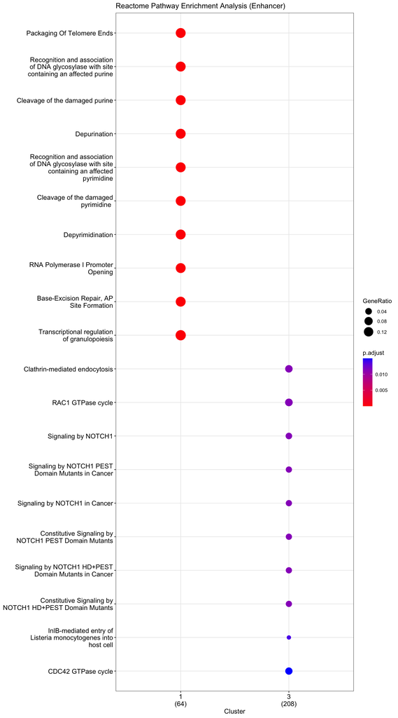

```r
> dotplot(PA.enhcr,
+         showCategory = 10,
+         title = "Reactome Pathway Enrichment Analysis (Enhancer)")
```

## Gene Ontology enrichment analysis

Exactly the same as above can be done with the function `enrichGO`.

```r
> GO.enhcr <- compareCluster(geneCluster = list.genes,
+                            fun = "enrichGO",
+                            OrgDb = org.Hs.eg.db,
+                            ont = "BP",
+                            readable = T,
+                            pvalueCutoff = 0.05,
+                            pAdjustMethod = "BH")
>
> GO.enhcr %>% as.data.frame() %>% paged_table()
```

| Cluster | ID | Description | GeneRatio | BgRatio | pvalue | p.adjust | qvalue | geneID | Count |
| --- | --- | --- | --- | --- | --- | --- | --- | --- | --- |
| 1 | GO:0006334 | nucleosome assembly | 9/81 | 118/18614 | 2.160730e-09 | 4.098904e-06 | 3.734650e-06 | H4C2/H1-6/H2BC4/H2BC7/H2BC8/H4C8/H4C9/H4C11/H4C12 | 9 |
| 1 | GO:0034728 | nucleosome organization | 9/81 | 138/18614 | 8.636310e-09 | 7.135200e-06 | 6.501122e-06 | H4C2/H1-6/H2BC4/H2BC7/H2BC8/H4C8/H4C9/H4C11/H4C12 | 9 |
| 1 | GO:0061644 | protein localization to CENP-A containing chromatin | 5/81 | 18/18614 | 1.128392e-08 | 7.135200e-06 | 6.501122e-06 | H4C2/H4C8/H4C9/H4C11/H4C12 | 5 |
| 1 | GO:0045653 | negative regulation of megakaryocyte differentiation | 5/81 | 20/18614 | 2.027987e-08 | 9.617730e-06 | 8.763040e-06 | H4C2/H4C8/H4C9/H4C11/H4C12 | 5 |
| 1 | GO:0071168 | protein localization to chromatin | 6/81 | 54/18614 | 1.229961e-07 | 4.666472e-05 | 4.251781e-05 | H4C2/H4C8/H4C9/H4C11/H4C12/ZMYND8 | 6 |
| 1 | GO:0002181 | cytoplasmic translation | 8/81 | 159/18614 | 4.504194e-07 | 1.424076e-04 | 1.297524e-04 | DPH5/RPL37A/RPSA/RPL22L1/RPS23/RPL10A/RPL36A/RPL17 | 8 |
| 1 | GO:0045652 | regulation of megakaryocyte differentiation | 5/81 | 38/18614 | 6.175291e-07 | 1.673504e-04 | 1.524786e-04 | H4C2/H4C8/H4C9/H4C11/H4C12 | 5 |
| 1 | GO:0065004 | protein-DNA complex assembly | 9/81 | 242/18614 | 1.057218e-06 | 2.454056e-04 | 2.235974e-04 | H4C2/H1-6/H2BC4/H2BC7/H2BC8/H4C8/H4C9/H4C11/H4C12 | 9 |
| 1 | GO:0071459 | protein localization to chromosome, centromeric region | 5/81 | 43/18614 | 1.164286e-06 | 2.454056e-04 | 2.235974e-04 | H4C2/H4C8/H4C9/H4C11/H4C12 | 5 |
| 1 | GO:0071824 | protein-DNA complex subunit organization | 9/81 | 263/18614 | 2.102828e-06 | 3.989064e-04 | 3.634572e-04 | H4C2/H1-6/H2BC4/H2BC7/H2BC8/H4C8/H4C9/H4C11/H4C12 | 9 |

[output cut: 72 more lines]

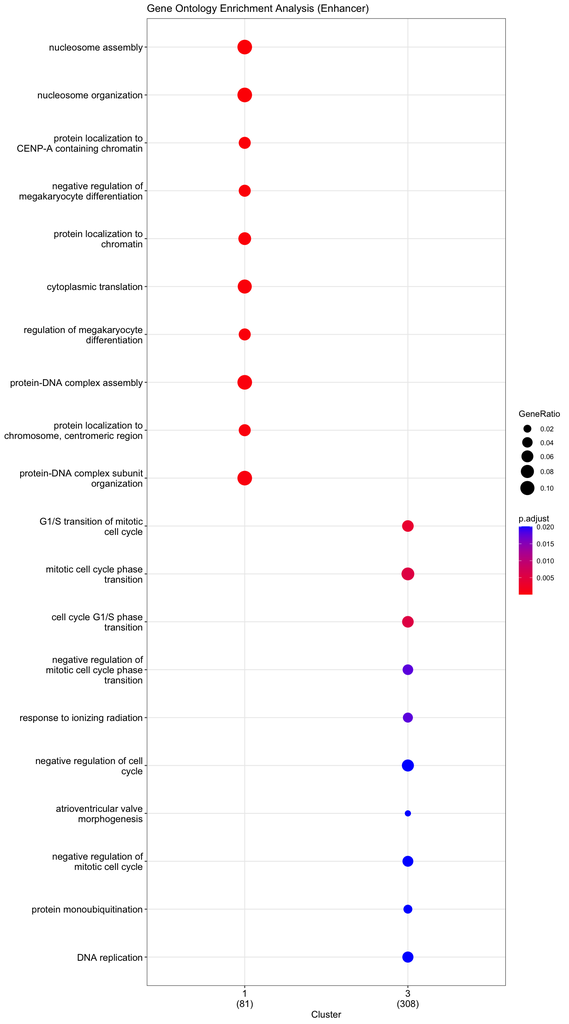

```r
> dotplot(GO.enhcr,
+         showCategory = 10,
+         title = "Gene Ontology Enrichment Analysis (Enhancer)")
```

## References - packages

- Allaire J, Xie Y, Dervieux C, McPherson J, Luraschi J, Ushey K, Atkins A, Wickham H, Cheng J, Chang W, Iannone R (2023). *rmarkdown: Dynamic Documents for R*. R package version 2.23, https://github.com/rstudio/rmarkdown. Xie Y, Allaire J, Grolemund G (2018). *R Markdown: The Definitive Guide*. Chapman and Hall/CRC, Boca Raton, Florida. ISBN 9781138359338, https://bookdown.org/yihui/rmarkdown. Xie Y, Dervieux C, Riederer E (2020). *R Markdown Cookbook*. Chapman and Hall/CRC, Boca Raton, Florida. ISBN 9780367563837, https://bookdown.org/yihui/rmarkdown-cookbook.
- Arora S, Morgan M, Carlson M, Pagès H (2023). *GenomeInfoDb: Utilities for manipulating chromosome names, including modifying them to follow a particular naming style*. doi:10.18129/B9.bioc.GenomeInfoDb https://doi.org/10.18129/B9.bioc.GenomeInfoDb, R package version 1.36.0, https://bioconductor.org/packages/GenomeInfoDb.
- Carlson M (2023). *org.Hs.eg.db: Genome wide annotation for Human*. R package version 3.17.0.
- Grolemund G, Wickham H (2011). “Dates and Times Made Easy with lubridate.” *Journal of Statistical Software*, *40*(3), 1-25. https://www.jstatsoft.org/v40/i03/.
- Huber W, Carey VJ, Gentleman R, Anders S, Carlson M, Carvalho BS, Bravo HC, Davis S, Gatto L, Girke T, Gottardo R, Hahne F, Hansen KD, Irizarry RA, Lawrence M, Love MI, MacDonald J, Obenchain V, Ole’s AK, Pag`es H, Reyes A, Shannon P, Smyth GK, Tenenbaum D, Waldron L, Morgan M (2015). “Orchestrating high-throughput genomic analysis with Bioconductor.” *Nature Methods*, *12*(2), 115-121. http://www.nature.com/nmeth/journal/v12/n2/full/nmeth.3252.html.
- Huber, W., Carey, J. V, Gentleman, R., Anders, S., Carlson, M., Carvalho, S. B, Bravo, C. H, Davis, S., Gatto, L., Girke, T., Gottardo, R., Hahne, F., Hansen, D. K, Irizarry, A. R, Lawrence, M., Love, I. M, MacDonald, J., Obenchain, V., Ole’s, K. A, Pag`es, H., Reyes, A., Shannon, P., Smyth, K. G, Tenenbaum, D., Waldron, L., Morgan, M. (2015). “Orchestrating high-throughput genomic analysis with Bioconductor.” *Nature Methods*, *12*(2), 115-121. http://www.nature.com/nmeth/journal/v12/n2/full/nmeth.3252.html.
- Lawrence M, Gentleman R, Carey V (2009). “rtracklayer: an R package for interfacing with genome browsers.” *Bioinformatics*, *25*, 1841-1842. doi:10.1093/bioinformatics/btp328 https://doi.org/10.1093/bioinformatics/btp328, http://bioinformatics.oxfordjournals.org/content/25/14/1841.abstract.
- Lawrence M, Huber W, Pagès H, Aboyoun P, Carlson M, Gentleman R, Morgan M, Carey V (2013). “Software for Computing and Annotating Genomic Ranges.” *PLoS Computational Biology*, *9*. doi:10.1371/journal.pcbi.1003118 https://doi.org/10.1371/journal.pcbi.1003118, http://www.ploscompbiol.org/article/info%3Adoi%2F10.1371%2Fjournal.pcbi.1003118.
- Lawrence M, Huber W, Pagès H, Aboyoun P, Carlson M, Gentleman R, Morgan M, Carey V (2013). “Software for Computing and Annotating Genomic Ranges.” *PLoS Computational Biology*, *9*. doi:10.1371/journal.pcbi.1003118 https://doi.org/10.1371/journal.pcbi.1003118, http://www.ploscompbiol.org/article/info%3Adoi%2F10.1371%2Fjournal.pcbi.1003118.
- Makowski D, Lüdecke D, Patil I, Thériault R, Ben-Shachar M, Wiernik B (2023). “Automated Results Reporting as a Practical Tool to Improve Reproducibility and Methodological Best Practices Adoption.” *CRAN*. https://easystats.github.io/report/.
- Müller K, Wickham H (2023). *tibble: Simple Data Frames*. R package version 3.2.1, https://CRAN.R-project.org/package=tibble.
- Pagès H, Carlson M, Falcon S, Li N (2023). *AnnotationDbi: Manipulation of SQLite-based annotations in Bioconductor*. doi:10.18129/B9.bioc.AnnotationDbi https://doi.org/10.18129/B9.bioc.AnnotationDbi, R package version 1.62.1, https://bioconductor.org/packages/AnnotationDbi.
- Pagès H, Lawrence M, Aboyoun P (2023). *S4Vectors: Foundation of vector-like and list-like containers in Bioconductor*. doi:10.18129/B9.bioc.S4Vectors https://doi.org/10.18129/B9.bioc.S4Vectors, R package version 0.38.1, https://bioconductor.org/packages/S4Vectors.
- R Core Team (2023). *R: A Language and Environment for Statistical Computing*. R Foundation for Statistical Computing, Vienna, Austria. https://www.R-project.org/.
- Wang Q, Li M, Wu T, Zhan L, Li L, Chen M, Xie W, Xie Z, Hu E, Xu S, Yu G (2022). “Exploring epigenomic datasets by ChIPseeker.” *Current Protocols*, *2*(10), e585. doi:10.1002/cpz1.585 https://doi.org/10.1002/cpz1.585, https://onlinelibrary.wiley.com/share/author/GYJGUBYCTRMYJFN2JFZZ?target=10.1002/cpz1.585. Yu G, Wang L, He Q (2015). “ChIPseeker: an R/Bioconductor package for ChIP peak annotation, comparison and visualization.” *Bioinformatics*, *31*(14), 2382-2383. doi:10.1093/bioinformatics/btv145 https://doi.org/10.1093/bioinformatics/btv145.
- Wickham H (2016). *ggplot2: Elegant Graphics for Data Analysis*. Springer-Verlag New York. ISBN 978-3-319-24277-4, https://ggplot2.tidyverse.org.
- Wickham H (2022). *stringr: Simple, Consistent Wrappers for Common String Operations*. R package version 1.5.0, https://CRAN.R-project.org/package=stringr.
- Wickham H (2023). *forcats: Tools for Working with Categorical Variables (Factors)*. R package version 1.0.0, https://CRAN.R-project.org/package=forcats.
- Wickham H, Averick M, Bryan J, Chang W, McGowan LD, François R, Grolemund G, Hayes A, Henry L, Hester J, Kuhn M, Pedersen TL, Miller E, Bache SM, Müller K, Ooms J, Robinson D, Seidel DP, Spinu V, Takahashi K, Vaughan D, Wilke C, Woo K, Yutani H (2019). “Welcome to the tidyverse.” *Journal of Open Source Software*, *4*(43), 1686. doi:10.21105/joss.01686 https://doi.org/10.21105/joss.01686.
- Wickham H, François R, Henry L, Müller K, Vaughan D (2023). *dplyr: A Grammar of Data Manipulation*. R package version 1.1.2, https://CRAN.R-project.org/package=dplyr.
- Wickham H, Henry L (2023). *purrr: Functional Programming Tools*. R package version 1.0.1, https://CRAN.R-project.org/package=purrr.
- Wickham H, Hester J, Bryan J (2023). *readr: Read Rectangular Text Data*. R package version 2.1.4, https://CRAN.R-project.org/package=readr.
- Wickham H, Vaughan D, Girlich M (2023). *tidyr: Tidy Messy Data*. R package version 1.3.0, https://CRAN.R-project.org/package=tidyr.
- Wu T, Hu E, Xu S, Chen M, Guo P, Dai Z, Feng T, Zhou L, Tang W, Zhan L, Fu x, Liu S, Bo X, Yu G (2021). “clusterProfiler 4.0: A universal enrichment tool for interpreting omics data.” *The Innovation*, *2*(3), 100141. doi:10.1016/j.xinn.2021.100141 https://doi.org/10.1016/j.xinn.2021.100141. Yu G, Wang L, Han Y, He Q (2012). “clusterProfiler: an R package for comparing biological themes among gene clusters.” *OMICS: A Journal of Integrative Biology*, *16*(5), 284-287. doi:10.1089/omi.2011.0118 https://doi.org/10.1089/omi.2011.0118.
- Xie Y (2023). *knitr: A General-Purpose Package for Dynamic Report Generation in R*. R package version 1.43, https://yihui.org/knitr/. Xie Y (2015). *Dynamic Documents with R and knitr*, 2nd edition. Chapman and Hall/CRC, Boca Raton, Florida. ISBN 978-1498716963, https://yihui.org/knitr/. Xie Y (2014). “knitr: A Comprehensive Tool for Reproducible Research in R.” In Stodden V, Leisch F, Peng RD (eds.), *Implementing Reproducible Computational Research*. Chapman and Hall/CRC. ISBN 978-1466561595.